# Google Data Analytics - Case Study 1

Jos Ignacio

2022-08-31

## Case Study 1: How Does a Bike-Share Navigate Speedy Success?

### Introduction

Cyclistic is a bike-share program that features more than 5,800 bicycles and 600 docking stations. To avail its program, customers can avail single-ride passes, full-day passes, and annual memberships. Customers who purchase single-ride or full-day passes are referred to as casual riders. Customers who purchase annual memberships are Cyclistic members.

### Business Task

Cyclistic’s finance analysts have concluded that annual members are much more profitable than casual riders. In order to convert casual riders into members, the marketing analyst team aims to design marketing strategies. The team must understand the difference between casual and member riders by analyzing Cyclistic historical bike trip data to identify trends.

### Preparing Data

Data to be used came from the module of the course and can be accessed [here](https://divvy-tripdata.s3.amazonaws.com/index.html). The data being used are from August 2021 to July 2022.

- Installing Required Packages

```r
library(tidyverse)
library(lubridate)
```

```r
library(ggplot2)
library(readxl)
library('scales')
```

- Importing Files
  - Setting Directories
  - Importing Files frrom August 2021 to July 2022

```r
setwd("F:/Code/Google Data Analytics/Case Study 1/202108-202207-tripdata-xlsx")
td_202108 <- read_excel("202108-divvy-tripdata.xlsx")
td_202109 <- read_excel("202109-divvy-tripdata.xlsx")
td_202110 <- read_excel("202110-divvy-tripdata.xlsx")
td_202111 <- read_excel("202111-divvy-tripdata.xlsx")
td_202112 <- read_excel("202112-divvy-tripdata.xlsx")
td_202112 <- read_excel("202112-divvy-tripdata.xlsx")
td_202201 <- read_excel("202201-divvy-tripdata.xlsx")
td_202202 <- read_excel("202202-divvy-tripdata.xlsx")
td_202203 <- read_excel("202203-divvy-tripdata.xlsx")
td_202204 <- read_excel("202204-divvy-tripdata.xlsx")
td_202205 <- read_excel("202205-divvy-tripdata.xlsx")
td_202206 <- read_excel("202206-divvy-tripdata.xlsx")
td_202207 <- read_excel("202207-divvy-tripdata.xlsx")
```

### Manipulating Data

- Merging All Files

```r
all_trips <- bind_rows(td_202108, td_202109, td_202110, td_202111, td_202112, td_202201, td_202202, td_202203, td_202204, td_202205, td_202206, td_202207)
head(all_trips)
```

```
## # A tibble: 6 x 15
##   ride_id        ridea~1 started_at          ended_at            start~2 start~3
##   <chr>          <chr>   <dttm>              <dttm>              <chr>   <chr>
## 1 99103BB87CC6C~ electr~ 2021-08-10 17:15:49 2021-08-10 17:22:44 <NA>    <NA>
## 2 EAFCCCFB0A3FC~ electr~ 2021-08-10 17:23:14 2021-08-10 17:39:24 <NA>    <NA>
## 3 9EF4F46C57AD2~ electr~ 2021-08-21 02:34:23 2021-08-21 02:50:36 <NA>    <NA>
## 4 5834D3208BFAF~ electr~ 2021-08-21 06:52:55 2021-08-21 07:08:13 <NA>    <NA>
## 5 CD825CB87ED1D~ electr~ 2021-08-19 11:55:29 2021-08-19 12:04:11 <NA>    <NA>
## 6 612F12C94A964~ electr~ 2021-08-19 12:41:12 2021-08-19 12:47:47 <NA>    <NA>
## # ... with 9 more variables: end_station_name <chr>, end_station_id <chr>,
## #   start_lat <dbl>, start_lng <dbl>, end_lat <dbl>, end_lng <dbl>,
## #   member_casual <chr>, ride_length <dttm>, day_of_week <dbl>, and abbreviated
## #   variable names 1: rideable_type, 2: start_station_name, 3: start_station_id
## # i Use `colnames()` to see all variable names
```

- Add Columns for Analysis
  - Ride Length

```r
all_trips$ride_length <- difftime(all_trips$ended_at,all_trips$started_at)
all_trips$ride_length <- as.numeric(as.character(all_trips$ride_length))
```

- Days of the Week

```r
all_trips$day_of_week <- format(as.Date(all_trips$started_at), "%A")
all_trips$day_of_week <- ordered(all_trips$day_of_week, levels=c("Sunday", "Monday", "Tuesday", "Wednesday", "Thursday", "Friday", "Saturday"))
```

- Month

```r
all_trips <- all_trips %>%
       mutate(year_month = strftime(all_trips$started_at, "%b"))
```

```r
all_trips <- all_trips %>%
            mutate(start_hour = format(as_datetime(all_trips$ended_at), "%H"))
head(all_trips)
```

```
## # A tibble: 6 x 17
##   ride_id        ridea~1 started_at          ended_at            start~2 start~3
##   <chr>          <chr>   <dttm>              <dttm>              <chr>   <chr>
## 1 99103BB87CC6C~ electr~ 2021-08-10 17:15:49 2021-08-10 17:22:44 <NA>    <NA>
## 2 EAFCCCFB0A3FC~ electr~ 2021-08-10 17:23:14 2021-08-10 17:39:24 <NA>    <NA>
## 3 9EF4F46C57AD2~ electr~ 2021-08-21 02:34:23 2021-08-21 02:50:36 <NA>    <NA>
## 4 5834D3208BFAF~ electr~ 2021-08-21 06:52:55 2021-08-21 07:08:13 <NA>    <NA>
## 5 CD825CB87ED1D~ electr~ 2021-08-19 11:55:29 2021-08-19 12:04:11 <NA>    <NA>
## 6 612F12C94A964~ electr~ 2021-08-19 12:41:12 2021-08-19 12:47:47 <NA>    <NA>
## # ... with 11 more variables: end_station_name <chr>, end_station_id <chr>,
## #   start_lat <dbl>, start_lng <dbl>, end_lat <dbl>, end_lng <dbl>,
## #   member_casual <chr>, ride_length <dbl>, day_of_week <ord>,
## #   year_month <chr>, start_hour <chr>, and abbreviated variable names
## #   1: rideable_type, 2: start_station_name, 3: start_station_id
## # i Use `colnames()` to see all variable names
```

### Cleaning Data

- Deleting Negative Ride Lengths

```r
all_trips_v2 <- all_trips[! (all_trips$ride_length<0),]
```

- Removing Duplicates

```r
all_trips_v2 <- all_trips_v2[!duplicated(all_trips_v2$ride_id),]
```

- Remove Irrelevant Columns

```r
all_trips_v2 <- all_trips_v2 %>%
   select(-c(start_lat, start_lng, end_lat, end_lng, start_station_id, start_station_name, end_station_name, end_station_id))
head(all_trips_v2)
```

```
## # A tibble: 6 x 9
##   ride_id        ridea~1 started_at          ended_at            membe~2 ride_~3
##   <chr>          <chr>   <dttm>              <dttm>              <chr>     <dbl>
## 1 99103BB87CC6C~ electr~ 2021-08-10 17:15:49 2021-08-10 17:22:44 member      415
## 2 EAFCCCFB0A3FC~ electr~ 2021-08-10 17:23:14 2021-08-10 17:39:24 member      970
## 3 9EF4F46C57AD2~ electr~ 2021-08-21 02:34:23 2021-08-21 02:50:36 member      973
## 4 5834D3208BFAF~ electr~ 2021-08-21 06:52:55 2021-08-21 07:08:13 member      918
## 5 CD825CB87ED1D~ electr~ 2021-08-19 11:55:29 2021-08-19 12:04:11 member      522
## 6 612F12C94A964~ electr~ 2021-08-19 12:41:12 2021-08-19 12:47:47 member      395
## # ... with 3 more variables: day_of_week <ord>, year_month <chr>,
## #   start_hour <chr>, and abbreviated variable names 1: rideable_type,
## #   2: member_casual, 3: ride_length
## # i Use `colnames()` to see all variable names
```

### Analyzing Data

1. Comparing Number of Casual vs Member Riders

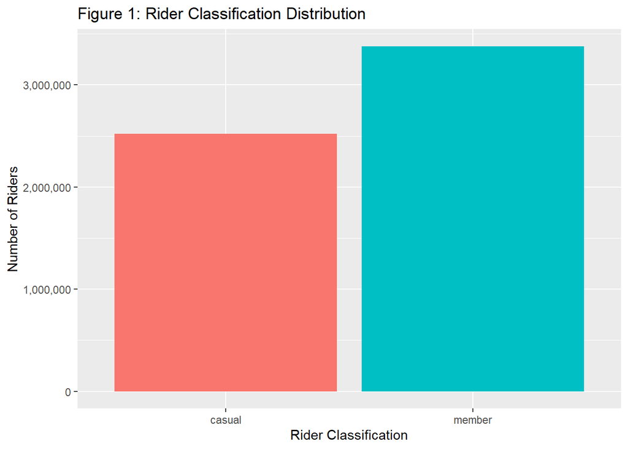

```r
fig <- function(width, heigth){options(repr.plot.width = width, repr.plot.height = heigth)}

fig(16,8)
ggplot(all_trips_v2, aes(member_casual, fill=member_casual)) +
  geom_bar() +
  labs(title="Figure 1: Rider Classification Distribution", x = 'Rider Classification', y = 'Number of Riders') +
  scale_y_continuous(labels = comma) +
  theme(legend.position = 'none')
```

There are more riders who availed membership than those who did not.

2. Observing Average Duration and Number of Rides of Casual and Member Riders based on Day

Getting the number of rides and average duration per day

```r
sum_day_of_week <- all_trips_v2 %>%
      group_by(member_casual, day_of_week) %>%
      summarise(number_of_rides = n(), average_duration = mean(ride_length)) %>%
      arrange(member_casual, day_of_week)
```

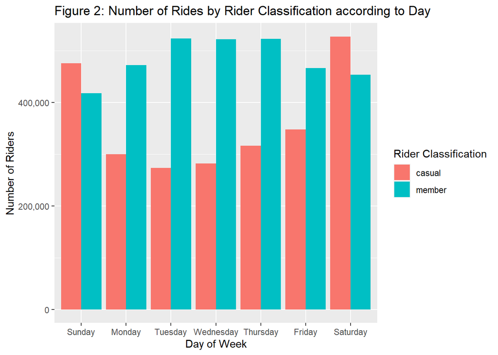

```r
fig(16,8)
ggplot(sum_day_of_week, aes(x = day_of_week, y = number_of_rides, fill=member_casual)) +
  geom_col(position = 'dodge') +
  labs(title="Figure 2: Number of Rides by Rider Classification according to Day", x = 'Day of Week', y = 'Number of Riders') +
  scale_y_continuous(labels = comma) +
  guides(fill = guide_legend(title = 'Rider Classification'))
```

There are more casual riders on weekends. ***

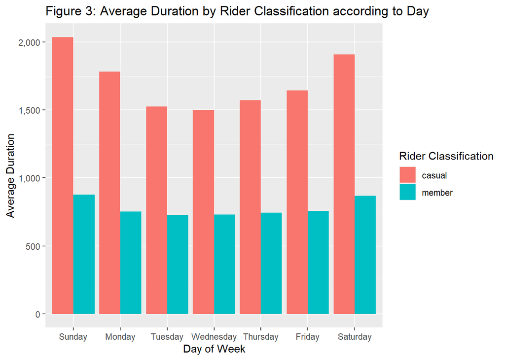

```r
fig(16,8)
ggplot(sum_day_of_week, aes(x = day_of_week, y = average_duration, fill=member_casual)) +
  geom_col(position = 'dodge') +
  labs(title="Figure 3: Average Duration by Rider Classification according to Day", x = 'Day of Week', y = 'Average Duration') +
  scale_y_continuous(labels = comma) +
  guides(fill = guide_legend(title = 'Rider Classification'))
```

Casual Riders spend more time riding especially on weekends than member riders. ***

3. Observing Average Duration and Number of Rides of Casual and Member Riders based on the Hour of the Day

Getting the number of rides and average duration per hour of the day

```r
sum_start_hour <- all_trips_v2 %>%
       group_by(member_casual, start_hour) %>%
     summarise(number_of_rides = n(), average_duration = mean(ride_length)) %>%
        arrange(member_casual, start_hour)
```

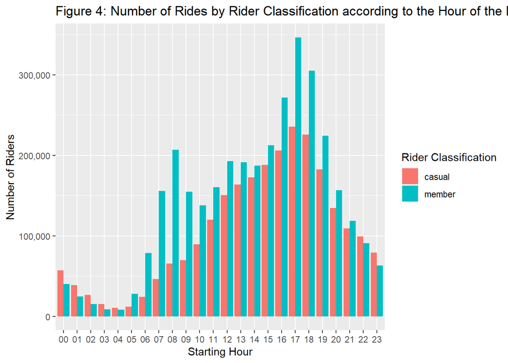

```r
fig(16,8)
ggplot(sum_start_hour, aes(x = start_hour, y = number_of_rides, fill=member_casual)) +
  geom_col(position = 'dodge') +
  labs(title="Figure 4: Number of Rides by Rider Classification according to the Hour of the Day", x = 'Starting Hour', y = 'Number of Riders') +
  scale_y_continuous(labels = comma) +
  guides(fill = guide_legend(title = 'Rider Classification'))
```

*** Majority of casual riders ride during the afternoon. Member riders ride from morning until the afternoon.

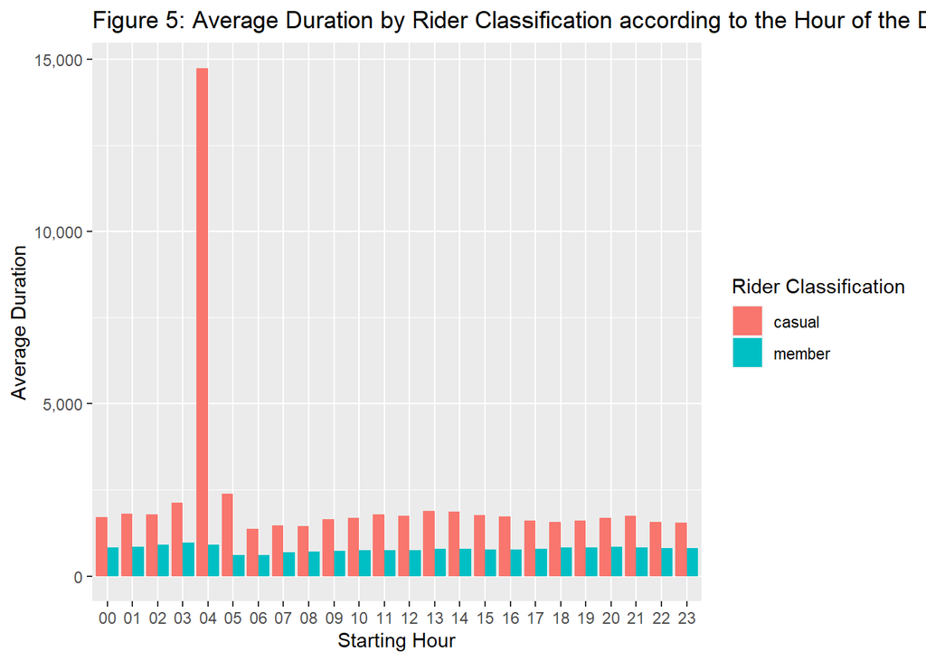

```r
fig(16,8)
ggplot(sum_start_hour, aes(x = start_hour, y = average_duration, fill=member_casual)) +
  geom_col(position = 'dodge') +
  labs(title="Figure 5: Average Duration by Rider Classification according to the Hour of the Day", x = 'Starting Hour', y = 'Average Duration') +
  scale_y_continuous(labels = comma) +
  guides(fill = guide_legend(title = 'Rider Classification'))
```

Casual riders spend more time riding than member riders. ***

4. Observing Average Duration and Number of Rides of Casual and Member Riders based on Month

Getting the number of rides and average duration per month

```r
sum_year_month <- all_trips_v2 %>%
      mutate(year_month = factor(year_month, levels = c("Jan", "Feb", "Mar", "Apr", "May", "Jun", "Jul", "Aug", "Sep", "Oct", "Nov", "Dec"))) %>%
       group_by(member_casual, year_month) %>%
       summarise(number_of_rides = n(), average_duration = mean(ride_length)) %>%
       arrange(member_casual, year_month)
```

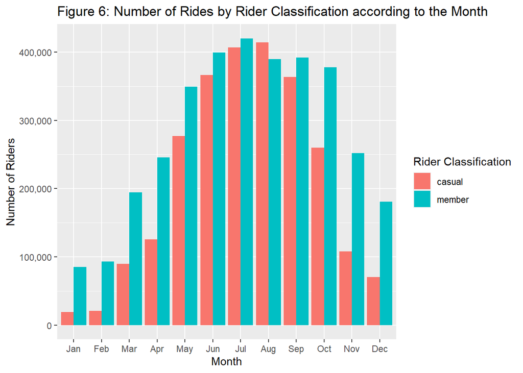

```r
fig(16,8)
ggplot(sum_year_month, aes(x = year_month, y = number_of_rides, fill=member_casual)) +
  geom_col(position = 'dodge') +
  labs(title="Figure 6: Number of Rides by Rider Classification according to the Month", x = 'Month', y = 'Number of Riders') +
  scale_y_continuous(labels = comma) +
  guides(fill = guide_legend(title = 'Rider Classification'))
```

Number of Riders peak from June to September. There are less riders from November to April. ***

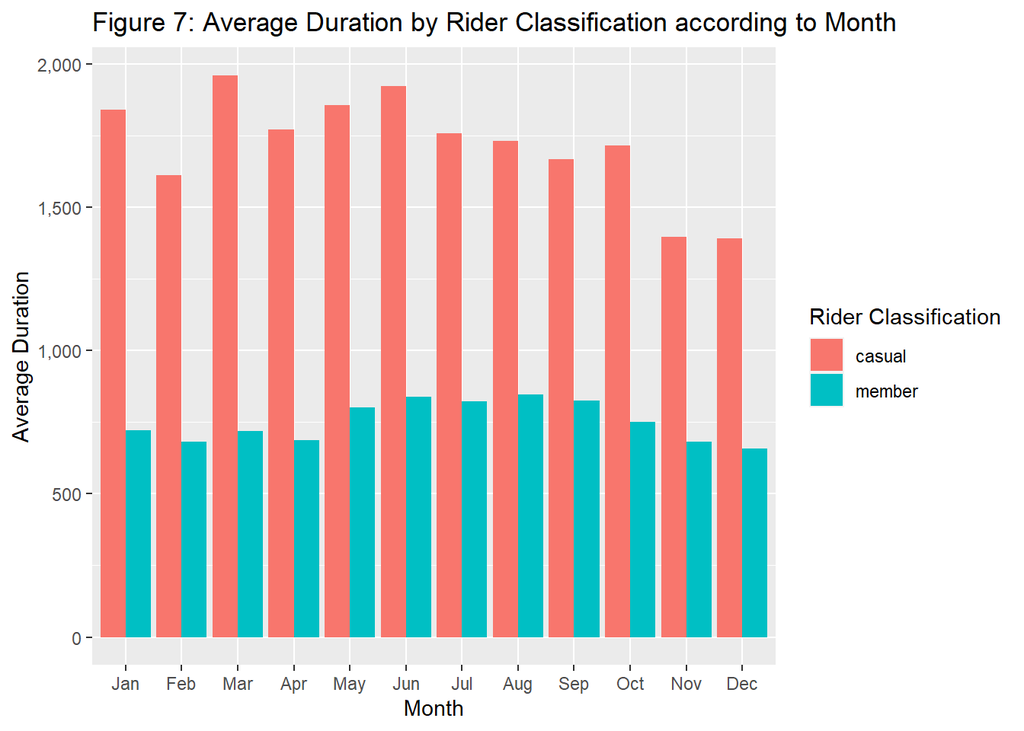

```r
fig(16,8)
ggplot(sum_year_month, aes(x = year_month, y = average_duration, fill=member_casual)) +
  geom_col(position = 'dodge') +
  labs(title="Figure 7: Average Duration by Rider Classification according to Month", x = 'Month', y = 'Average Duration') +
  scale_y_continuous(labels = comma) +
  guides(fill = guide_legend(title = 'Rider Classification'))
```

Casual riders spend more time riding than member riders.

5. Observing Average Duration and Number of Rides of Casual and Member Riders based on Rideable Type

Getting the number of rides and average duration per rideable type

```r
sum_rideable_type <- all_trips_v2 %>%
       group_by(member_casual, rideable_type) %>%
       summarise(number_of_rides = n(), average_duration = mean(ride_length)) %>%
       arrange(member_casual, rideable_type)
```

[figure not shown]

```r
fig(16,8)
ggplot(sum_rideable_type, aes(x = rideable_type, y = number_of_rides, fill=member_casual)) +
  geom_col(position = 'dodge') +
  labs(title="Figure 6: Number of Rides by Rider Classification according to the Month", x = 'Rideable Type', y = 'Number of Riders') +
  scale_y_continuous(labels = comma) +
  guides(fill = guide_legend(title = 'Rider Classification'))
```

Casual riders has an almost equal amount of riders using a classic bike and an electric bike. Casual riders also use docked bikes. Member riders use the classic bike more often. ***

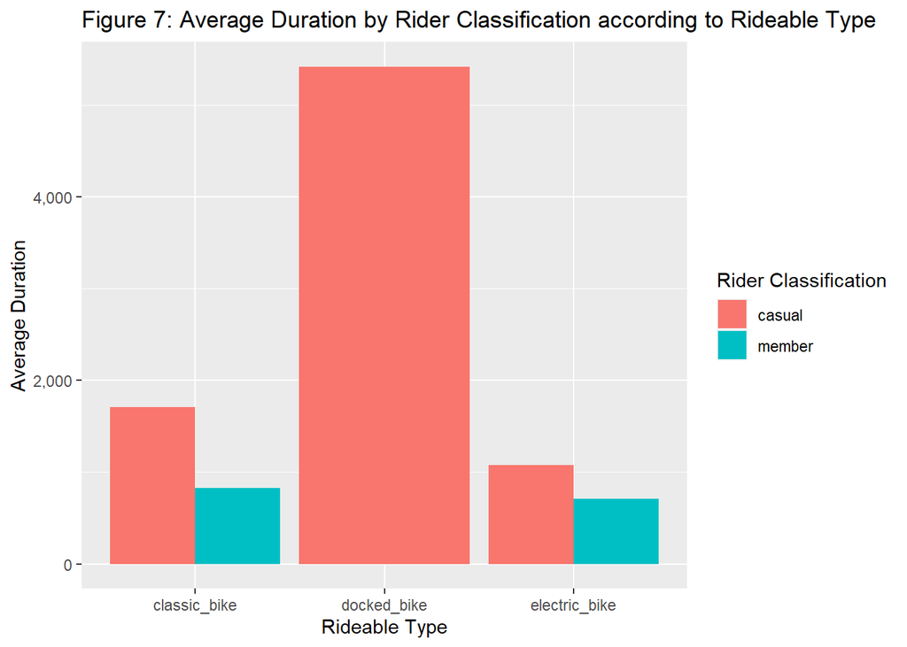

```r
fig(16,8)
ggplot(sum_rideable_type, aes(x = rideable_type, y = average_duration, fill=member_casual)) +
  geom_col(position = 'dodge') +
  labs(title="Figure 7: Average Duration by Rider Classification according to Rideable Type", x = 'Rideable Type', y = 'Average Duration') +
  scale_y_continuous(labels = comma) +
  guides(fill = guide_legend(title = 'Rider Classification'))
```

### Recommendations

To increase casual rider to member rider conversion, the recommendations are the following: 1. Have a ride length limit for casual riders. 2. Promote benefits of biking during the morning and weekdays. 3. Have membership discounts during peak seasons.